# Badanie statystyk ofensywnych najskuteczniejszych piłkarzy w sezonie 2022/23 w top 5 ligach Europejskich

Wojciech Liberacki

2023-12-15

# 1 . Dane

Dane przedstawiają statystyki 35 piłkarzy z największą liczbą bramek zdobytych w najlepszych pięciu ligach Europejskich (angielskiej, hiszpańskiej, włoskiej, niemieckiej i francuskiej) w sezonie 2022/23

```r
topscorers <- read.csv("C:/Users/wojte/OneDrive/Desktop/Projekty/Statystyczna_analiza_danych/topscorers.csv")
```

```r
topscorers$PKmiss<- topscorers$PK-topscorers$PKatt
topscorers$GlsPer90Min <- topscorers$Gls/(topscorers$Min/90)
topscorers$Min <- NULL
topscorers$Ast <- NULL
topscorers$PK <- NULL
topscorers$PKatt <- NULL
topscorers
```

```
##                 Player Gls G.Sh G.xG SoT. Dist PKmiss GlsPer90Min
## 1       Erling Haaland  36 0.25  7.6 45.7 12.6      0   1.1700975
## 2           Harry Kane  30 0.20  8.5 43.5 16.0     -1   0.7929515
## 3        Kylian Mbappé  29 0.18  2.7 50.7 15.9     -2   0.9261888
## 4  Alexandre Lacazette  27 0.20  2.8 43.9 14.4     -2   0.8296347
## 5       Victor Osimhen  26 0.18  4.7 39.4 12.8     -1   0.9119252
## 6       Jonathan David  24 0.15  0.4 46.3 15.8     -1   0.6822489
## 7   Robert Lewandowski  23 0.17 -1.3 41.8 13.8     -1   0.7270811
## 8      Folarin Balogun  21 0.12 -5.6 41.3 15.2     -1   0.6302101
## 9          Loïs Openda  21 0.19  2.6 47.6 13.1      0   0.7508939
## 10    Lautaro Martínez  21 0.16  2.9 40.8 15.1     -1   0.7336957
## 11        Habib Diallo  20 0.19  2.2 40.0 13.0     -1   0.6252171
## 12          Ivan Toney  20 0.16  1.3 37.9 16.5     -1   0.6099627
## 13           Elye Wahi  19 0.29  6.8 58.1 14.5      0   0.6804616
## 14       Karim Benzema  19 0.12 -2.5 36.4 15.9     -1   0.8390579
```

[output cut: 21 more lines]

## Zmienne:

• Gls: bramki zdobyte  
• G.Sh: bramki zdobyte / ilość oddanych strzałów  
• G.xG: bramki zdobyte - expected Goals(statystyka określająca bramki oczekiwane)  
• Dist: średnia odległość oddawanego strzału  
• PKmiss: rzuty karne niestrzelone (np. -1 - jeden karny niestrzelony)  
• GlsPer90Min: bramki zdobyte na 90 minut piłkarza na boisku

# 2 . Charakterystyka zmiennych

## Statystyki opisowe

```r
summary(topscorers)
```

```
##     Player               Gls            G.Sh            G.xG
##  Length:35          Min.   :15.0   Min.   :0.120   Min.   :-5.600
##  Class :character   1st Qu.:15.0   1st Qu.:0.150   1st Qu.: 0.900
##  Mode  :character   Median :18.0   Median :0.170   Median : 2.500
##                     Mean   :19.2   Mean   :0.178   Mean   : 2.303
##                     3rd Qu.:21.0   3rd Qu.:0.190   3rd Qu.: 3.750
##                     Max.   :36.0   Max.   :0.320   Max.   : 8.500
##       SoT.            Dist           PKmiss         GlsPer90Min
##  Min.   :31.50   Min.   :12.40   Min.   :-2.0000   Min.   :0.4317
##  1st Qu.:37.95   1st Qu.:14.00   1st Qu.:-1.0000   1st Qu.:0.5103
##  Median :41.80   Median :15.20   Median :-1.0000   Median :0.5969
##  Mean   :42.56   Mean   :15.31   Mean   :-0.6571   Mean   :0.6455
##  3rd Qu.:45.55   3rd Qu.:16.00   3rd Qu.: 0.0000   3rd Qu.:0.7550
##  Max.   :58.10   Max.   :22.60   Max.   : 0.0000   Max.   :1.1701
```

## Współczynniki zmienności

```r
coefficient_of_variation<- function(x) {
  cv <- sd(x) / abs(mean(x))
  return(cv)
}
cvs <- sapply(topscorers[,-1], coefficient_of_variation)
cvs
```

```
##         Gls        G.Sh        G.xG        SoT.        Dist      PKmiss
##   0.2685019   0.2444267   1.2994680   0.1445827   0.1367710   0.9724894
## GlsPer90Min
##   0.2643011
```

Współczynniki zmiennośći dla każdej zmiennej są większe od 0.1, więc nie ma tu problemu w kontekście analizy skupień.

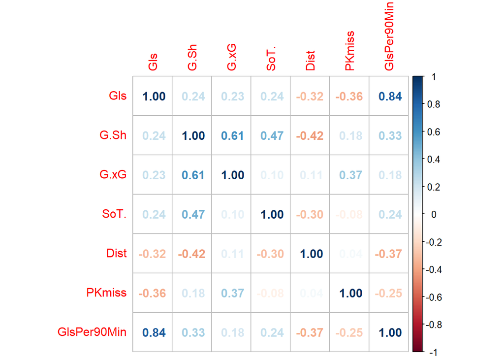

```r
library(corrplot)
cor_matrix <- cor(topscorers[,-1])
corrplot(cor_matrix, method = "number")
```

Dla wszystkich par zmiennych korelacja na moduł mniejsza niż 0.9, więc nie ma powodu do odrzucenia do analizy skupień.

# 3. Cel projektu

Celem projektu jest analiza najlepiej strzelających zawodników top 5 lig piłkarskich, stworzenie rankingu najlepszych napastników (i graczy ofensywnych) w oparciu o statystyki definiujące jakość piłkarza i jego umiejętność strzelania bramek. Analiza ma też na celu wyłonić grupę “nieoczywistych” zawodników z predyzpozycjami na stanowienie samej czołówki ogólnej klasyfikacji strzelców(zawodnicy skuteczni z niekoniecznie najwyższą ilością bramek).

# 4. Porządkowanie liniowe

## Metoda Hellwiga z rangami

1. Wszystkie zmienne są stumulantami dlatego je standaryzuje

```r
topscorers_scaled <- topscorers

variables_to_standardize <- c("Gls", "G.Sh", "G.xG", "SoT.", "Dist", "PKmiss", "GlsPer90Min")

topscorers_scaled[, variables_to_standardize] <- scale(topscorers_scaled[, variables_to_standardize])
```

2. Wartość maksymalna z każdej kolumny

```r
pattern <- apply(topscorers_scaled[,2:8],2,max)
pattern
```

```
##         Gls        G.Sh        G.xG        SoT.        Dist      PKmiss
##    3.258822    3.263772    2.070899    2.525417    3.478414    1.028289
## GlsPer90Min
##    3.074494
```

```r
wages <- c(0.125,0.25,0.25,0.05,0.05,0.1,0.1,0.175)
distances <- apply(topscorers_scaled[,2:8], 1,  function(row) {sqrt(sum(wages*(row-pattern)^2))})
distances
```

```
##  [1] 1.418621 1.954376 2.418375 2.476569 2.480052 3.007867 3.116560 3.951687
##  [9] 2.742528 2.954943 2.996248 3.162840 2.243470 3.698351 2.775573 3.833212
## [17] 2.882767 2.967009 3.292028 2.585960 3.331162 3.646869 3.174228 3.690608
## [25] 3.616418 3.368976 3.189061 3.387957 3.557453 3.393795 3.375620 3.301757
## [33] 3.745072 3.488347 3.550543
```

4. Odległość “możliwie daleka”

```r
max_dist <- mean(distances) + 2*sd(distances)
max_dist
```

```
## [1] 4.229464
```

5. Obliczone współczynniki:

```r
hellwig <- c(1- distances/max_dist)
result<- data.frame(topscorers[,1], hellwig)
names(result) <- c("name","hellwig")
result[order(result$hellwig, decreasing = TRUE), ]
```

```
##                   name    hellwig
## 1       Erling Haaland 0.66458606
## 2           Harry Kane 0.53791406
## 13           Elye Wahi 0.46956155
## 3        Kylian Mbappé 0.42820776
## 4  Alexandre Lacazette 0.41444848
## 5       Victor Osimhen 0.41362500
## 20         Boulaye Dia 0.38858449
## 9          Loïs Openda 0.35156604
## 15   Wissam Ben Yedder 0.34375313
## 17         Terem Moffi 0.31840840
## 10    Lautaro Martínez 0.30134350
## 18       Callum Wilson 0.29849050
## 11        Habib Diallo 0.29157741
## 6       Jonathan David 0.28883034
```

[output cut: 21 more lines]

## Interpretacja

Bez zaskoczenia Erling Haaland okazał się najlepszym napastnikiem. Jednak analiza przyniosła porządany efekt, pokazała ona dużo większą jakość strzelecką takich zawodników jak Wahi (miejsce w rankingu: 13 -> 3) czy Dia ( 20 - > 7) i niższą niż ta na pierwszy rzut oka widoczna, takich zawodników jak Lewandowski (7 - > 15).

# 5. Analiza skupień

## Odleglosci miedzy obiektami(metoda Euklidesowa):

```r
library(clusterSim)
data_distances <- dist(topscorers_scaled[,2:8], method = "euclidean")
```

## Metoda Warda

```r
data_groups <- hclust(data_distances, method ="ward.D")
data_groups
```

```
##
## Call:
## hclust(d = data_distances, method = "ward.D")
##
## Cluster method   : ward.D
## Distance         : euclidean
## Number of objects: 35
```

## Dendogram

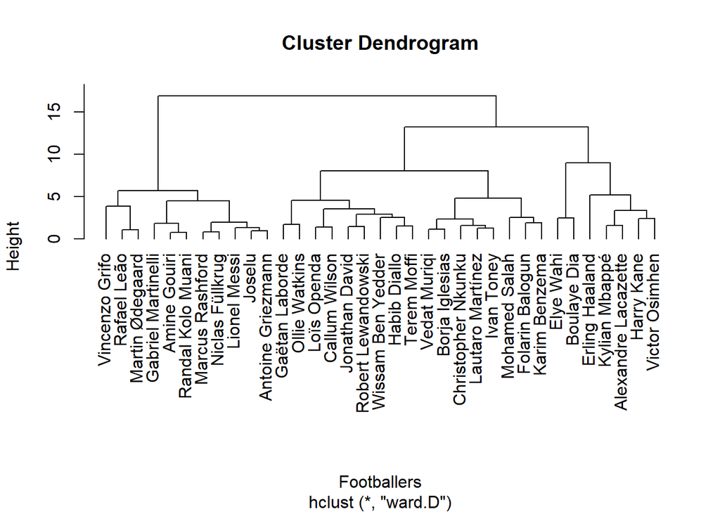

```r
dendogram <-plot(data_groups, labels = topscorers[,1], xlab="Footballers", hang = -1)
```

### Sprawdzam, która liczba grup (2 lub 3) jest bardziej opytymalna przy pomocy indeksów:

## Silhouette

```r
index.S(data_distances, cutree(data_groups, k=2))
```

```
## [1] 0.1762526
```

```r
index.S(data_distances, cutree(data_groups, k=3))
```

```
## [1] 0.1919911
```

## Huberta i Levine’a

```r
index.G3(data_distances, cutree(data_groups, k=2))
```

```
## [1] 0.3736044
```

```r
index.G3(data_distances, cutree(data_groups, k=3))
```

```
## [1] 0.3847736
```

## Bakera i Huberta

```r
index.G2(data_distances, cutree(data_groups, k=2))
```

```
## [1] 0.2564772
```

```r
index.G2(data_distances, cutree(data_groups, k=3))
```

```
## [1] 0.5810385
```